# CSE 6242 Activity 1

Vincent La (Georgia Tech ID - vla6)

September 12, 2017

# Loading the Data

First, we load the data. The first thing we’re going to look at is temperature. I find this interesting because I have this hypothesis that students in the United States of America are more likely to record their temperatures in Fahrenheit. Students in other parts of the world are more likely to record their temperatures in Celsius. I want to better explore the temperatures recorded in this data set.

```r
# Activity 1: http://cse6242.gatech.edu/fall-2017/ac1/
# To compile R Markdown in terminal run: Rscript -e "rmarkdown::render('ac1.Rmd', clean=TRUE)"
require(stringr)
```

```r
require(ggplot2)
require(gridExtra)
df = read.csv('ac1_survey.csv')
print(unique(df$timestamp))
```

```
##   [1] 2017/08/21 9:35:02 AM MDT  2017/08/21 6:16:02 PM MDT
##   [3] 2017/08/21 6:35:21 PM MDT  2017/08/21 7:13:48 PM MDT
##   [5] 2017/08/22 3:38:36 AM MDT  2017/08/22 8:33:15 PM MDT
##   [7] 2017/08/23 7:57:21 AM MDT  2017/08/23 9:32:40 AM MDT
##   [9] 2017/08/23 12:24:32 PM MDT 2017/08/23 12:25:36 PM MDT
##  [11] 2017/08/23 4:18:39 PM MDT  2017/08/24 7:49:33 AM MDT
##  [13] 2017/08/24 1:57:44 PM MDT  2017/08/25 9:49:00 AM MDT
##  [15] 2017/08/25 2:14:11 PM MDT  2017/08/26 10:32:59 AM MDT
##  [17] 2017/08/26 11:56:50 AM MDT 2017/08/27 12:21:14 AM MDT
##  [19] 2017/08/27 4:06:10 AM MDT  2017/08/27 10:33:43 AM MDT
##  [21] 2017/08/27 10:39:47 AM MDT 2017/08/27 10:43:50 AM MDT
##  [23] 2017/08/27 11:22:17 AM MDT 2017/08/27 2:03:44 PM MDT
##  [25] 2017/08/27 2:18:17 PM MDT  2017/08/27 3:00:07 PM MDT
##  [27] 2017/08/27 3:24:34 PM MDT  2017/08/27 3:35:31 PM MDT
##  [29] 2017/08/27 4:51:25 PM MDT  2017/08/27 5:14:52 PM MDT
```

[output cut: 96 more lines]

```r
df$timestamp_cleaned = strptime(df$timestamp, "%Y/%m/%d %I:%M:%S %p", tz = "US/Mountain")


df$max_temp_cleaned = str_extract(df$max_temp,"\\(?[0-9,.]+\\)?")
df$max_temp_cleaned = as.numeric(df$max_temp_cleaned)

df$temp_type = ifelse(str_detect(df$max_temp, 'F'), "Fahrenheit",
               ifelse(str_detect(df$max_temp, 'C'), "Celsius",
               'Unspecified'))

print(head(df))
```

```
##                   timestamp fav_num max_temp comic_char music_genre
## 1 2017/08/21 9:35:02 AM MDT      42       84     Naruto     Country
## 2 2017/08/21 6:16:02 PM MDT      32       80   Superman        Rock
## 3 2017/08/21 6:35:21 PM MDT      21       91      Flash     Hip-Hop
## 4 2017/08/21 7:13:48 PM MDT      39      91F  Spiderman         EDM
## 5 2017/08/22 3:38:36 AM MDT       6    102.2     Batman     New Age
## 6 2017/08/22 8:33:15 PM MDT       3       80     Batman     Country
##   total_rain                               book_title book_pages
## 1       28.2 How to make friends and influence people        288
## 2         45                          Executive Power        512
## 3         54                                Waking Up        312
## 4      38.69                                     1q84        928
## 5         42                              Game Theory        310
## 6         50                                   See Me        486
##     timestamp_cleaned max_temp_cleaned   temp_type
## 1 2017-08-21 09:35:02             84.0 Unspecified
## 2 2017-08-21 18:16:02             80.0 Unspecified
## 3 2017-08-21 18:35:21             91.0 Unspecified
## 4 2017-08-21 19:13:48             91.0  Fahrenheit
## 5 2017-08-22 03:38:36            102.2 Unspecified
## 6 2017-08-22 20:33:15             80.0 Unspecified
```

```r
summary(df)
```

```
##                      timestamp      fav_num       max_temp
##  2017/08/21 6:16:02 PM MDT:  1   7      : 40   80     : 13
##  2017/08/21 6:35:21 PM MDT:  1   42     : 13   82     :  9
##  2017/08/21 7:13:48 PM MDT:  1   3      : 12   90     :  9
##  2017/08/21 9:35:02 AM MDT:  1   8      : 12   75     :  8
##  2017/08/22 3:38:36 AM MDT:  1   1      : 10   78     :  7
##  2017/08/22 8:33:15 PM MDT:  1   4      : 10   86     :  7
##  (Other)                  :214   (Other):123   (Other):167
##      comic_char   music_genre   total_rain             book_title
##  Batman   : 26   Rock   :61   42     :  7   Machine Learning:  4
##  Spiderman: 13   Pop    :42   45.18  :  7   Deep Learning   :  3
##  Superman : 13   Country:21          :  6   The Martian     :  3
##  Iron Man : 10   Hip-Hop:17   35.48  :  6                   :  2
##  Wolverine:  8   Jazz   :14   38.7   :  6   A Clash of Kings:  2
##           :  6   Blues  : 8   (Other):187   Freakonomics    :  2
##  (Other)  :144   (Other):57   NA's   :  1   (Other)         :204
##    book_pages     timestamp_cleaned             max_temp_cleaned
##  Min.   :   0.0   Min.   :2017-08-21 09:35:02   Min.   : 15.00
##  1st Qu.: 300.0   1st Qu.:2017-08-28 19:25:00   1st Qu.: 74.00
##  Median : 384.0   Median :2017-08-29 08:08:06   Median : 80.00
##  Mean   : 462.3   Mean   :2017-08-30 00:47:11   Mean   : 76.84
##  3rd Qu.: 572.0   3rd Qu.:2017-08-31 17:34:57   3rd Qu.: 88.00
##  Max.   :2570.0   Max.   :2017-09-04 22:08:29   Max.   :113.00
##  NA's   :2
##   temp_type
##  Length:220
##  Class :character
##  Mode  :character
##
##
##
##
```

After cleaning the data and converting to a numeric, we can plot some distributions.

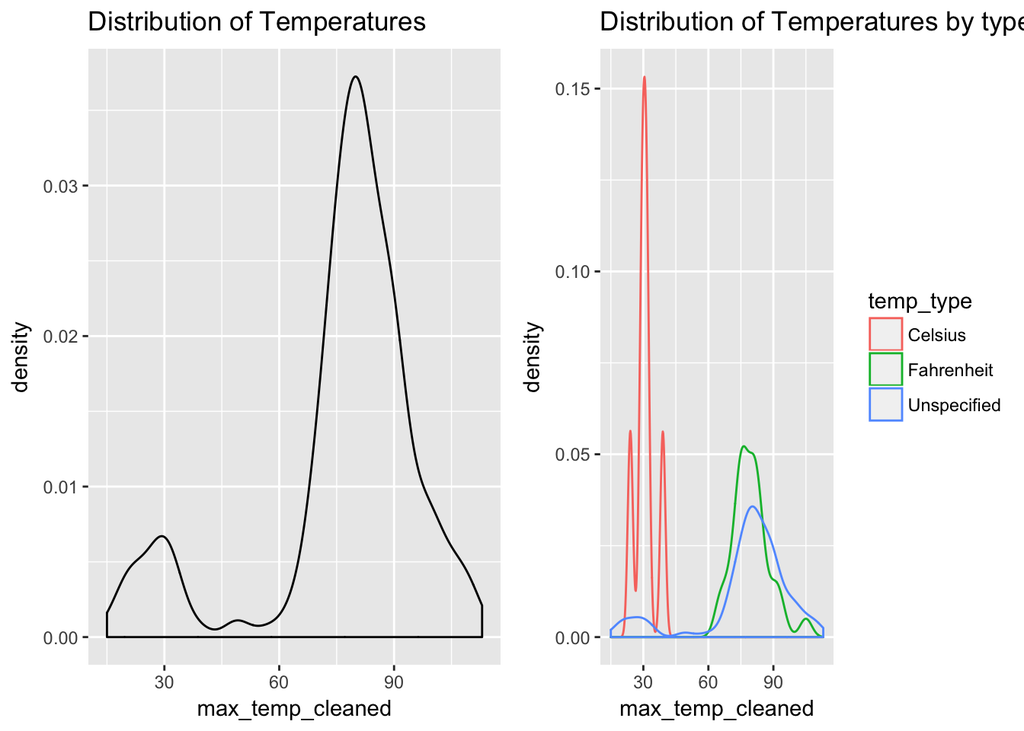

```r
agg_plot = ggplot(df, aes(x=max_temp_cleaned)) +
             geom_density(aes()) +
             ggtitle('Distribution of Temperatures')

# Plotting temperature density plots by temperature type
grouped_plot = ggplot(df, aes(x=max_temp_cleaned)) +
                 geom_density(aes(color=temp_type, group=temp_type)) +
                 ggtitle('Distribution of Temperatures by type')

grid.arrange(agg_plot, grouped_plot, ncol=2)
```

The first plot is a plot of the distribution of all the temperatures recorded. The second plot is a plot grouped by the temperature type recorded (e.g. Fahrenheit or Celsius). If the temperature type was not inputted, we default to a value “Unspecified”.

In the second plot, we can look more directly at the temperatures by type. For the temperatures that were recorded as Celsius, most of the temperatures recorded are around 30 degrees. For Fahrenheit, most of the temperatures recorded are around 70 to 80 degrees. This makes sense as it is the summer for the northern hemisphere. For the data points that are “Unspecified”, the distribution looks similar to the aggregate distribution.